# Smart_Beta

## Smart Beta

### Specify inputs

```r
start <- as.Date("2010-12-31")
end <- as.Date("2017-12-31")

# The following 3 specify how many of the top contenders out
# of 30 DJIA components should be selected for the smart beta strategy
n_momentum <- 15
n_lowvol <- 15
n_combination <- 15
```

### Import libraries

```r
library(lubridate)
library(quantmod)
library(purrr)
library(xml2)
library(rvest)
library(Quandl)
Quandl.api_key("M2-Rpsxfj4vXk5_22GAV")
```

### DEFINE HELPER FUNCTIONS

```r
isTopN<-function(vec, N){
  1+length(vec)-rank(vec) <= N
}

isBottomN<-function(vec, N){
  rank(vec) <= N
}

get_DJ_symbols<-function(){
  wiki<-"https://en.wikipedia.org/wiki/Dow_Jones_Industrial_Average"
  htmldocobj<-read_html(wiki)
  DJIA <- html_table(htmldocobj, fill=T)[[2]]
  companies <- DJIA$Company
  symbols <- DJIA$Symbol
  names(symbols)<-companies
  return(symbols)
}

getPriceSeries<-function(symbol) {
  getSymbols(symbol, src = "yahoo",from = start, to = end, auto.assign = F)[,4]
}

getDailyReturn <- function(priceSeries){
  out<- dailyReturn(priceSeries)
  out<- out[2:nrow(out)]
  names(out)<-names(priceSeries)
  return(out)
}

retDfSum <- function(retDF){
  apply(retDF, 2, function(rets){prod(1+rets)-1})
}
```

### IMPLEMENTING SMART-BETA

```r
# Get prices for constituents
symbols<- get_DJ_symbols()
allPrices <- map(symbols, getPriceSeries )
```

[output not shown]

[output not shown]

```r
names(allPrices) <- symbols

# Compute returns from prices
dailyReturns <- map(allPrices, getDailyReturn)
dailyReturns <- Reduce(cbind, dailyReturns)
monthlyReturns <- apply.monthly(dailyReturns, retDfSum)

# Compute signal for Low-vol strategy: Rolling 3-month daily-vol
rolling_3mo_daily_vol <- apply.monthly(na.trim(rollapply(dailyReturns, 63, sd)), last)

# Compute signal for Momentum strategy: Rolling 12-month return
rolling_12mo_returns<- na.trim(rollapply(monthlyReturns, 12, retDfSum))

# Compute signal for Combination strategy: Rolling 12-month return/Rolling 3-month daily-vol
combination_signal <- rolling_12mo_returns/rolling_3mo_daily_vol
```

### MOMENTUM STRATEGY

```r
wts_momentum <- t(apply(rolling_12mo_returns, 1, isTopN, n_momentum)) * (1/n_momentum)
wts_momentum <- xts(wts_momentum, order.by=as.Date(rownames(wts_momentum)))
momentum_return_contributions <- na.trim(lag(wts_momentum, 1)) * monthlyReturns
momentum_returns <- apply(momentum_return_contributions, 1, sum)
momentum_returns <- xts(momentum_returns, order.by=as.Date(names(momentum_returns)))
names(momentum_returns) <- "momentum"
```

### LOW-VOL STRATEGY

```r
wts_lowvol <- t(apply(rolling_3mo_daily_vol, 1, isBottomN, n_lowvol)) * (1/n_lowvol)
wts_lowvol <- xts(wts_lowvol, order.by=as.Date(rownames(wts_lowvol)))
lowvol_return_contributions <- na.trim(lag(wts_lowvol, 1)) * monthlyReturns
lowvol_returns <- apply(lowvol_return_contributions, 1, sum)
lowvol_returns <- xts(lowvol_returns, order.by=as.Date(names(lowvol_returns)))
names(lowvol_returns)<-"lowvol"
```

### COMBINATION STRATEGY

```r
wts_combination <- t(apply(combination_signal, 1, isTopN, n_combination)) * (1/n_combination)
wts_combination <- xts(wts_combination, order.by=as.Date(rownames(wts_combination)))
combination_return_contributions <- na.trim(lag(wts_combination, 1)) * monthlyReturns
combination_returns <- apply(combination_return_contributions, 1, sum)
combination_returns <- xts(combination_returns, order.by=as.Date(names(combination_returns)))
names(combination_returns)<-"combination"
```

### DOW JONES INDEX

```r
dji <- getSymbols("^DJI", from=start, to=end, auto.assign = F)[,4]
dji_monthly <- apply.monthly(dji, last)
dji_returns <- monthlyReturn(dji_monthly)
names(dji_returns)<-"djia"
```

### PLOT

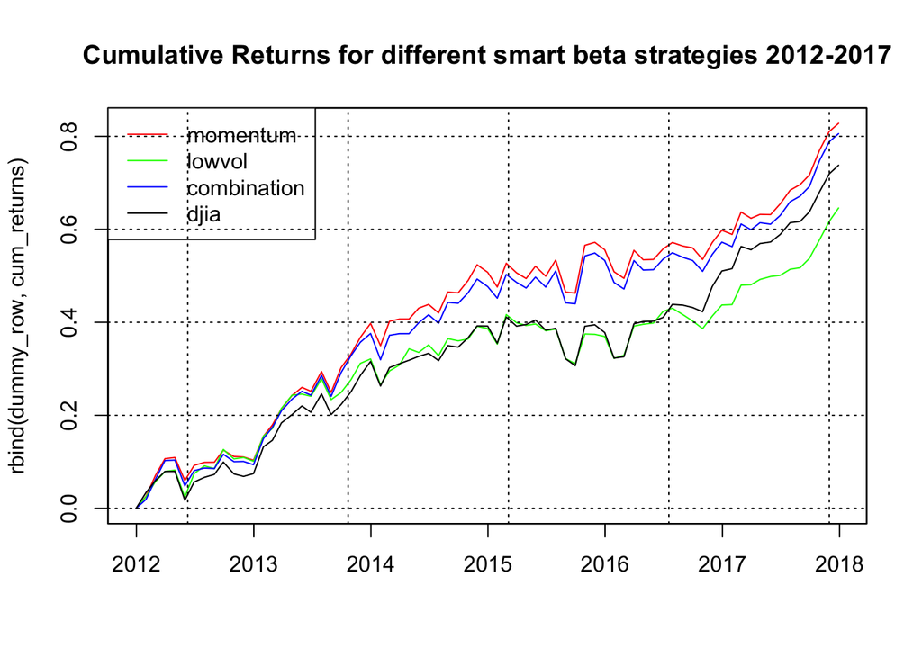

```r
strategies <- na.trim(cbind(momentum_returns, lowvol_returns, combination_returns, dji_returns))
cum_returns <- cumsum(strategies)
dummy_row <- do.call(cbind, map(1:4,function(x){xts(0, order.by = head(index(cum_returns),1)-months(1))}))
names(dummy_row) <- names(cum_returns)
plot.zoo( rbind(dummy_row,cum_returns), screens=1, col = c("red", "green", "blue", "black"), main="Cumulative Returns for different smart beta strategies 2012-2017", xlab = "", )
legend("topleft", legend=names(cum_returns), col = c("red", "green", "blue", "black"), lty=1 )
grid(col="black")
```

### TABLE

```r
library(PerformanceAnalytics)
table.AnnualizedReturns(strategies)
```

```
##                           momentum lowvol combination   djia
## Annualized Return           0.1409 0.1082      0.1366 0.1246
## Annualized Std Dev          0.1055 0.0955      0.1065 0.1002
## Annualized Sharpe (Rf=0%)   1.3359 1.1327      1.2831 1.2441
```

# Thoughts on pros

1. Both the momentum and combination strategies performed better than DJIA on both return and sharpe, and can be used fruitfully to trade.

### Final thoughts on cons and improvement

1. Strategy suffers from survivorship bias. We chose the constituents on DJIA as they are today, but ran our backtest back to 2012 when some of the constituents were different. This gives us an unfair advantage in backtest. Ideally, the universe at any given point should also only consist of the DJIA constituent at that time. This is an improvement needed in this strategy backtest.
2. We have not taken into account transaction costs, which would further reduce the backtest PNL.
3. We have not taken into account sector exposures, and may end up with unwanted tilts or inappropriately high exposure in specific sectors.
4. Based on the beta of the strategies, we can infer if we have unintended bets on the broad market. That tilt can be fixed by optimizing the weights.
5. The strategy equally weights the securities it selects based on any given signal. We can possibly enhance performance by giving more weight those securities that rank higher than others.